# Practical Machine Learning Project

## Introduction

The purpose of this project is to use sensor data from six participants to predict whether the subjects were correctly performing barbell lifts. The data consists of readings from accelerometers attached to the subjects’ belts, forearms and arms and the dumbbell itself.

## Downloading the Data

Here we download the training and test data and set up the dataframe to perform exploratory data analysis and modelling.

```r
library(dplyr)
```

```r
library(ggplot2)


# download.file('https://d396qusza40orc.cloudfront.net/predmachlearn/pml-training.csv', destfile = 'pml-training.csv')
#
# download.file('https://d396qusza40orc.cloudfront.net/predmachlearn/pml-testing.csv', destfile = 'pml-testing.csv')

training <- read.csv('pml-training.csv', stringsAsFactors = TRUE)
testing <- read.csv('pml-testing.csv', stringsAsFactors = TRUE)

## There are a lot of columns with NAs
## We will eliminate those columns
null_cols <- apply(is.na(training), 2, sum)
null_cols <-names(which(null_cols!=0, useNames = TRUE))

## Additionally many column consist primarily of blank values
## We will eliminate those as well
blank_cols <- apply(training=='', 2, sum)
blank_cols <- names(which(blank_cols!=0, useNames = TRUE))

# Other uninteresting columns, for example X is just an id.
other_cols <- c('X','user_name')
time_cols <- names(training)[grepl('timestamp',names(training))]
cols_to_omit <- c(other_cols, null_cols, blank_cols, time_cols)
cols_to_omit <- unique(cols_to_omit)

cols_to_retain <- names(training)[!(names(training) %in% cols_to_omit)]

training <- training[,cols_to_retain]

# exclude the classe column for the testing set
cols_to_retain <- cols_to_retain[!(cols_to_retain =='classe')]
testing <- testing[,cols_to_retain]
```

## Exploratory Data Analysis

Among the remaining variables we will look for any correlations or other patterns tha might help guide our feature selection an modeling process.

Are any of the remaining numeric columns composed of only a single value? If so, we can probably omit those.

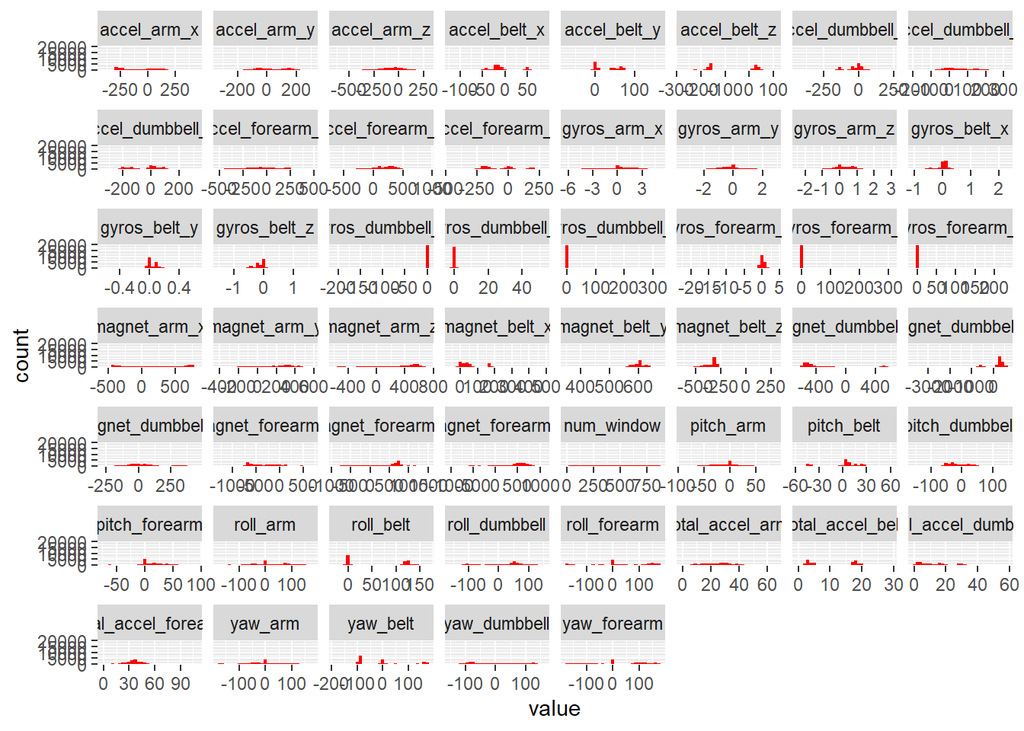

```r
numeric_cols <- names(training)[sapply(training, class) %in% c('integer','numeric')]
## 54 numeric columns

training_numeric <- training[,numeric_cols]

library(tidyr)

training_numeric_gathered <- training_numeric %>% gather()

### not printing plot to reduce file size
ggplot(training_numeric_gathered, aes(value)) +
  geom_histogram(fill='red') + facet_wrap(~key, scales = 'free_x')
```

```r
rm(training_numeric_gathered)
```

Look at correlation between the remaining variables. We could eliminate any perfectly correlated variables here.

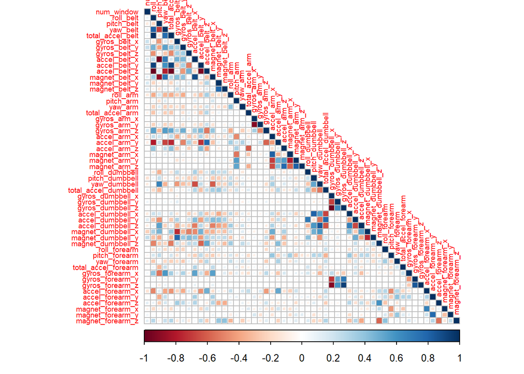

```r
library(corrplot)
mat <- cor(training[,-c(1,55)])
corrplot(mat, type = 'lower', method = 'square', tl.cex = 0.6)
```

Only a handful of variables show a high degree of correlation.

Lets group each of the variables by class to detect any patterns of interest.

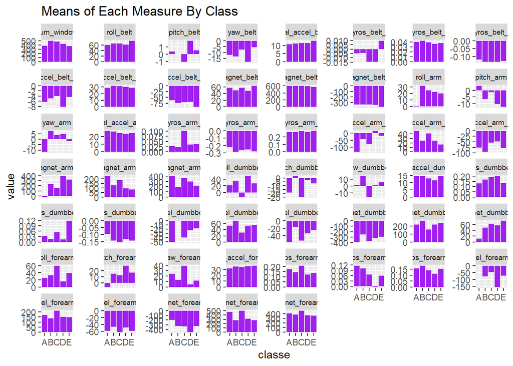

```r
training_grouped <- training %>%
  group_by(classe) %>%
  summarise(across(
    .cols = is.numeric,
    .fns = list(Mean = mean), na.rm = TRUE,
    .names = "{col}"
    ))


library(reshape2)
training_grouped <- melt(training_grouped, id.vars = 'classe')

ggplot(training_grouped, aes(classe, value)) + geom_bar(stat='identity', fill = 'purple') +
  facet_wrap(.~variable, scales = 'free_y') + ggtitle('Means of Each Measure By Class') +
  theme(strip.text.x = element_text(size = 7))
```

## Modeling

Subdivide our training data set into a training and testing (validation) data sets.

```r
library(caret)
# subdivide training into a training and test set
inTrain <- createDataPartition(training$classe, p = 0.7, list = FALSE)

training.train <- training[inTrain,]
training.test <- training[-inTrain,]
```

First we will start with a random forest model using all the available variables.

```r
set.seed(14197)
mod_rf <- train(classe ~ ., data=training.train, method = 'rf', trControl=trainControl(method='none'),
                tuneGrid=data.frame(mtry=7))
```

Using the final model parameters we can then assess model accuracy on the validation set.

```r
pred_rf <- predict(mod_rf, training.test)
confusionMatrix(pred_rf, training.test$classe)
```

```
## Confusion Matrix and Statistics
##
##           Reference
## Prediction    A    B    C    D    E
##          A 1672    0    0    0    0
##          B    1 1139    1    0    0
##          C    0    0 1025    4    0
##          D    0    0    0  960    2
##          E    1    0    0    0 1080
##
## Overall Statistics
##
##                Accuracy : 0.9985
##                  95% CI : (0.9971, 0.9993)
##     No Information Rate : 0.2845
##     P-Value [Acc > NIR] : < 2.2e-16
##
##                   Kappa : 0.9981
##
##  Mcnemar's Test P-Value : NA
##
## Statistics by Class:
##
##                      Class: A Class: B Class: C Class: D Class: E
## Sensitivity            0.9988   1.0000   0.9990   0.9959   0.9982
## Specificity            1.0000   0.9996   0.9992   0.9996   0.9998
## Pos Pred Value         1.0000   0.9982   0.9961   0.9979   0.9991
## Neg Pred Value         0.9995   1.0000   0.9998   0.9992   0.9996
## Prevalence             0.2845   0.1935   0.1743   0.1638   0.1839
## Detection Rate         0.2841   0.1935   0.1742   0.1631   0.1835
## Detection Prevalence   0.2841   0.1939   0.1749   0.1635   0.1837
## Balanced Accuracy      0.9994   0.9998   0.9991   0.9977   0.9990
```

As a second approach we will try to model using a classification tree

```r
mod_tree <- train(classe ~ ., method="rpart", data=training.train)

pred_tree <- predict(mod_tree, training.test)
confusionMatrix(pred_tree, training.test$classe)
```

```
## Confusion Matrix and Statistics
##
##           Reference
## Prediction    A    B    C    D    E
##          A 1521  472  469  434  152
##          B   31  383   37  187  130
##          C  119  284  520  343  309
##          D    0    0    0    0    0
##          E    3    0    0    0  491
##
## Overall Statistics
##
##                Accuracy : 0.4953
##                  95% CI : (0.4825, 0.5082)
##     No Information Rate : 0.2845
##     P-Value [Acc > NIR] : < 2.2e-16
##
##                   Kappa : 0.3406
##
##  Mcnemar's Test P-Value : NA
##
## Statistics by Class:
##
##                      Class: A Class: B Class: C Class: D Class: E
## Sensitivity            0.9086  0.33626  0.50682   0.0000  0.45379
## Specificity            0.6374  0.91888  0.78288   1.0000  0.99938
## Pos Pred Value         0.4990  0.49870  0.33016      NaN  0.99393
## Neg Pred Value         0.9461  0.85226  0.88260   0.8362  0.89037
## Prevalence             0.2845  0.19354  0.17434   0.1638  0.18386
## Detection Rate         0.2585  0.06508  0.08836   0.0000  0.08343
## Detection Prevalence   0.5179  0.13050  0.26763   0.0000  0.08394
## Balanced Accuracy      0.7730  0.62757  0.64485   0.5000  0.72658
```

As a final modeling approach, we will try generalized boosted model.

```r
mod_gbm <- train(classe ~ ., method='gbm', data=training.train, verbose=FALSE,
                 trControl=trainControl(method="cv", number=2, allowParallel=TRUE))

pred_gbm <- predict(mod_gbm, training.test)
confusionMatrix(pred_gbm, training.test$classe)
```

```
## Confusion Matrix and Statistics
##
##           Reference
## Prediction    A    B    C    D    E
##          A 1669   14    0    0    0
##          B    5 1119   14    0    2
##          C    0    5 1010   12    2
##          D    0    1    2  951    8
##          E    0    0    0    1 1070
##
## Overall Statistics
##
##                Accuracy : 0.9888
##                  95% CI : (0.9858, 0.9913)
##     No Information Rate : 0.2845
##     P-Value [Acc > NIR] : < 2.2e-16
##
##                   Kappa : 0.9858
##
##  Mcnemar's Test P-Value : NA
##
## Statistics by Class:
##
##                      Class: A Class: B Class: C Class: D Class: E
## Sensitivity            0.9970   0.9824   0.9844   0.9865   0.9889
## Specificity            0.9967   0.9956   0.9961   0.9978   0.9998
## Pos Pred Value         0.9917   0.9816   0.9815   0.9886   0.9991
## Neg Pred Value         0.9988   0.9958   0.9967   0.9974   0.9975
## Prevalence             0.2845   0.1935   0.1743   0.1638   0.1839
## Detection Rate         0.2836   0.1901   0.1716   0.1616   0.1818
## Detection Prevalence   0.2860   0.1937   0.1749   0.1635   0.1820
## Balanced Accuracy      0.9968   0.9890   0.9902   0.9921   0.9944
```

## Conclusion

```r
pred_final <- predict(mod_rf, testing)

pred_final
```

```
##  [1] B A B A A E D B A A B C B A E E A B B B
## Levels: A B C D E
```